# Modèles de classification appliquées au marketing bancaire

Charbel AHOUANDOKOUN, Nazifou AFOLABI

02 avril, 2023

# I- Etude:

## 1- Base de données:

La présente étude porte sur les données liées aux campagnes de marketing direct d’une institution bancaire portugaise en 2014. L’objectif de la classification est de prédire si le client souscrira un dépôt à terme (variable y). Elle est accessible en ligne, [ici](https://archive.ics.uci.edu/ml/datasets/Bank+Marketing). Elle contient 45211 observations de 17. Les observations manquantes sont codées comme modalité $unknown$ pour chaque variables.

## 2- Statistiques descriptives:

### - Variables quantitatives

Le tableau ci-dessous présente les principales grandeurs statistiques des variables quantitatives de notre base de données.

Stats descriptives-Variables quantitatives

[output not shown]

### - Variables qualitatives

Les proportions de chaque modalité selon que les individus aient contracté ou pas un dépôt à terme sont présentées dans le tableau ci-dessous.

| **Characteristic** | **no**, N = 39,922<sup>1</sup> | **yes**, N = 5,289<sup>1</sup> |
| --- | --- | --- |
| job |  |  |
| admin. | 4,540 (88%) | 631 (12%) |
| blue-collar | 9,024 (93%) | 708 (7.3%) |
| entrepreneur | 1,364 (92%) | 123 (8.3%) |
| housemaid | 1,131 (91%) | 109 (8.8%) |
| management | 8,157 (86%) | 1,301 (14%) |
| retired | 1,748 (77%) | 516 (23%) |
| self-employed | 1,392 (88%) | 187 (12%) |
| services | 3,785 (91%) | 369 (8.9%) |
| student | 669 (71%) | 269 (29%) |
| technician | 6,757 (89%) | 840 (11%) |
| unemployed | 1,101 (84%) | 202 (16%) |
| unknown | 254 (88%) | 34 (12%) |
| marital |  |  |
| divorced | 4,585 (88%) | 622 (12%) |
| married | 24,459 (90%) | 2,755 (10%) |
| single | 10,878 (85%) | 1,912 (15%) |
| education |  |  |
| primary | 6,260 (91%) | 591 (8.6%) |
| secondary | 20,752 (89%) | 2,450 (11%) |
| tertiary | 11,305 (85%) | 1,996 (15%) |
| unknown | 1,605 (86%) | 252 (14%) |
| default | 763 (94%) | 52 (6.4%) |
| housing | 23,195 (92%) | 1,935 (7.7%) |
| loan | 6,760 (93%) | 484 (6.7%) |
| contact |  |  |
| cellular | 24,916 (85%) | 4,369 (15%) |
| telephone | 2,516 (87%) | 390 (13%) |
| unknown | 12,490 (96%) | 530 (4.1%) |
| poutcome |  |  |
| failure | 4,283 (87%) | 618 (13%) |
| other | 1,533 (83%) | 307 (17%) |
| success | 533 (35%) | 978 (65%) |
| unknown | 33,573 (91%) | 3,386 (9.2%) |

<sup>1</sup> n (%)

#### Lecture du tableau

# II- Modèles de type Analyse Factorielles Discriminantes

Nous allons déployer ici, les modèles de classification tel que l’**Analyse Linéaire Discriminante** ($LDA$) et l’**Analyse Quadratique Discriminante** ($QDA$).

## 1- LDA

Le présent tableau représente le résumé de la classification des individus selon notre modèle, elle confronte les prédictions de notre modèle aux données de notre base.

Matrice de confusion - LDA

| Prediction | Realité no | Realité yes | Sum |
| --- | --- | --- | --- |
| no | 12824 | 992 | 13816 |
| yes | 489 | 766 | 1255 |
| Sum | 13313 | 1758 | 15071 |

A partir de ce tableau, on peut relever la $sensibilité$ (les $yes$ correctement classés par notre modèle) qui est de 43.57% et la $spécificité$ (les $no$ correctement prédits) évalué à 96.33%.

## 2- QDA

Nous présentons ici la même matrice, pour le modèle $QDA$.

Matrice de confusion - QDA

| Prediction | Realité no | Realité yes | Sum |
| --- | --- | --- | --- |
| no | 12259 | 899 | 13158 |
| yes | 1054 | 859 | 1913 |
| Sum | 13313 | 1758 | 15071 |

La sensibilité du modèle est de 48.86% contre 92.08% pour la spécificité.

## 3- Table de précisions

La table suivante présente les **précisions** en entraînement et test ainsi que l’**aire sous la courbe ROC** pour chacun de nos modèles, il sera mis à jour de façon automatique tout au long de notre travail.

Table de précision

| Modèles | Précision_Train | Précision_Test | Aire_roc |
| --- | --- | --- | --- |
| LDA | 0.9005 | 0.9017 | 0.9093 |
| QDA | 0.8715 | 0.8704 | 0.8457 |

# III - Modèles de Support Vector Machine

## 1- SVM Linéaire

Après optimisation via validation croisée, le paramètre **cost** optimal est $0.0131$.

Matrice de confusion - SVM Linéaire

| Prediction | Realité no | Realité yes | Sum |
| --- | --- | --- | --- |
| no | 13131 | 1428 | 14559 |
| yes | 182 | 330 | 512 |
| Sum | 13313 | 1758 | 15071 |

## 2- SVM Radial

Les paramètres optimaux sont: $1$ pour le **cost** et $0.25$ pour le **rbf_sigma**.

Matrice de confusion - SVM Radial

| Prediction | Realité no | Realité yes | Sum |
| --- | --- | --- | --- |
| no | 13001 | 1092 | 14093 |
| yes | 312 | 666 | 978 |
| Sum | 13313 | 1758 | 15071 |

## 3- Table de précisions:

Table de précision

| Modèles | Précision_Train | Précision_Test | Aire_roc |
| --- | --- | --- | --- |
| LDA | 0.9005 | 0.9017 | 0.9093 |
| QDA | 0.8715 | 0.8704 | 0.8457 |
| SVM linéaire | 0.8927 | 0.8932 | 0.9040 |
| SVM radial | 0.9437 | 0.9068 | 0.9041 |

# IV- Modèle KNN

Le **nombre de voisins** optimal est de $38$.

1- Matrice de confusion

Matrice de confusion - KNN

| Prediction | Realité no | Realité yes | Sum |
| --- | --- | --- | --- |
| no | 13059 | 1233 | 14292 |
| yes | 254 | 525 | 779 |
| Sum | 13313 | 1758 | 15071 |

## 2- Table de précisions:

Table de précision

| Modèles | Précision_Train | Précision_Test | Aire_roc |
| --- | --- | --- | --- |
| LDA | 0.9005 | 0.9017 | 0.9093 |
| QDA | 0.8715 | 0.8704 | 0.8457 |
| SVM linéaire | 0.8927 | 0.8932 | 0.9040 |
| SVM radial | 0.9437 | 0.9068 | 0.9041 |
| KNN | 0.9096 | 0.9013 | 0.8947 |

# V- Arbre CART

La valeur optimale du paramètre **cost_complexity** est de $0.00631$.

## 1- Matrice de confusion

Matrice de confusion - Tree

| Prediction | Realité no | Realité yes | Sum |
| --- | --- | --- | --- |
| no | 12883 | 1035 | 13918 |
| yes | 430 | 723 | 1153 |
| Sum | 13313 | 1758 | 15071 |

## 2- ARBRE

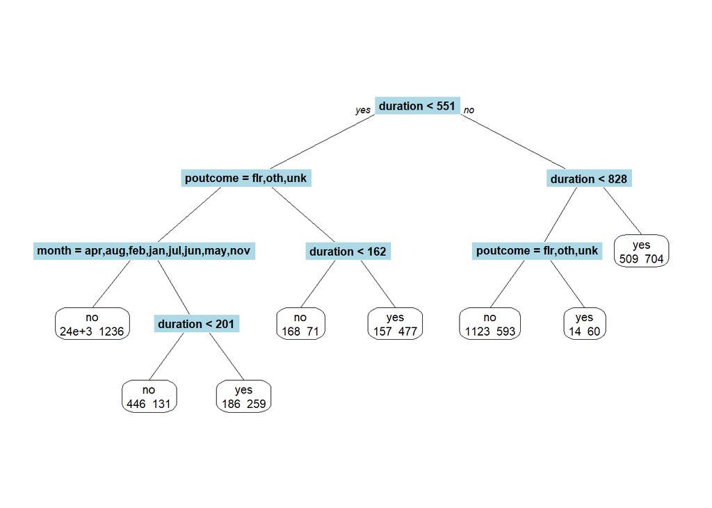

## 3- Table de précisions:

Table de précision

| Modèles | Précision_Train | Précision_Test | Aire_roc |
| --- | --- | --- | --- |
| LDA | 0.9005 | 0.9017 | 0.9093 |
| QDA | 0.8715 | 0.8704 | 0.8457 |
| SVM linéaire | 0.8927 | 0.8932 | 0.9040 |
| SVM radial | 0.9437 | 0.9068 | 0.9041 |
| KNN | 0.9096 | 0.9013 | 0.8947 |
| Tree | 0.9039 | 0.9028 | 0.7875 |

# VI- Random Forest

Les valeurs optimales des paramètres sont : $500$ pour le **nombre d’arbre**, $12$ pour le nombre de prédicteurs par noeud (**mtry**) et $40$ pour le **min_n**.

## 1- Matrice de Confusion

Matrice de confusion - RandomForest

| Prediction | Realité no | Realité yes | Sum |
| --- | --- | --- | --- |
| no | 12864 | 907 | 13771 |
| yes | 449 | 851 | 1300 |
| Sum | 13313 | 1758 | 15071 |

## 2- Table de précisions:

Table de précision

| Modèles | Précision_Train | Précision_Test | Aire_roc |
| --- | --- | --- | --- |
| LDA | 0.9005 | 0.9017 | 0.9093 |
| QDA | 0.8715 | 0.8704 | 0.8457 |
| SVM linéaire | 0.8927 | 0.8932 | 0.9040 |
| SVM radial | 0.9437 | 0.9068 | 0.9041 |
| KNN | 0.9096 | 0.9013 | 0.8947 |
| Tree | 0.9039 | 0.9028 | 0.7875 |
| RForest | 0.9399 | 0.9100 | 0.9335 |

# VII- Boosting

Valeurs optimales:

- nombre d’arbres (**trees**): $2000$
- profondeur (**tree_depth**): $15$
- **learn_rate**: $0.001$
- **loss_reduction**: $1.e-10$
- **sample_size**: $0.1$

## 1- Matrice de Confusion

Matrice de confusion - Boosting

| Prediction | Realité no | Realité yes | Sum |
| --- | --- | --- | --- |
| no | 12915 | 1029 | 13944 |
| yes | 398 | 729 | 1127 |
| Sum | 13313 | 1758 | 15071 |

## 2- Table de précisions:

Table de précision

| Modèles | Précision_Train | Précision_Test | Aire_roc |
| --- | --- | --- | --- |
| LDA | 0.9005 | 0.9017 | 0.9093 |
| QDA | 0.8715 | 0.8704 | 0.8457 |
| SVM linéaire | 0.8927 | 0.8932 | 0.9040 |
| SVM radial | 0.9437 | 0.9068 | 0.9041 |
| KNN | 0.9096 | 0.9013 | 0.8947 |
| Tree | 0.9039 | 0.9028 | 0.7875 |
| RForest | 0.9399 | 0.9100 | 0.9335 |
| Boosting | 0.9160 | 0.9053 | 0.9237 |

# VIII- Logit

Le choix du seuil optimal dépend du taux de précisions atteint selon les valeurs du seuil. Le graphique suivant permet d’identifier ce seuil.

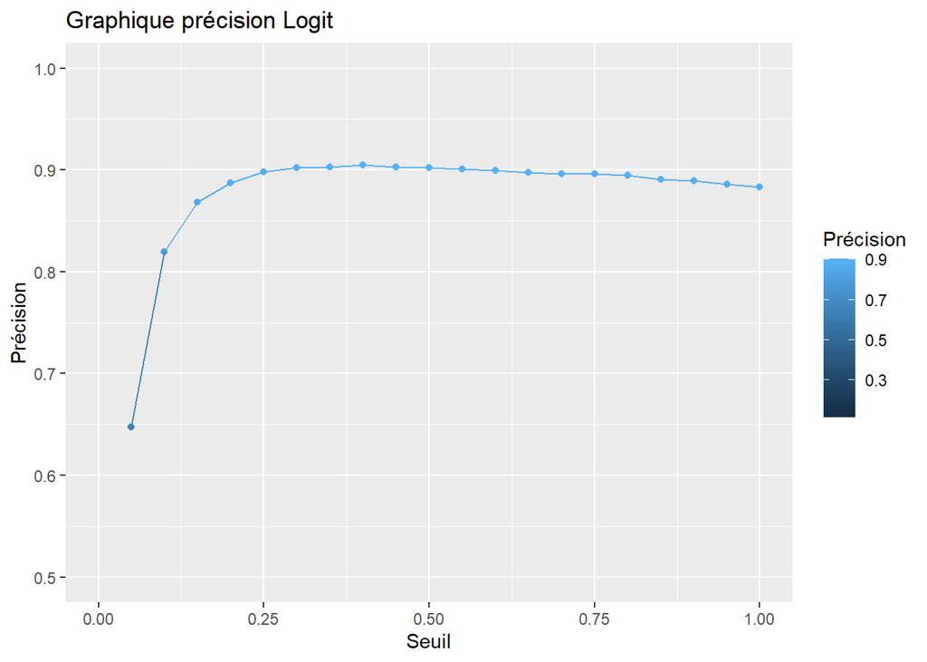

Table de choix seuil -Logit

|  | 5 | 6 | 7 | 8 | 9 | 10 | 11 | 12 | 13 | 14 | 15 |
| --- | --- | --- | --- | --- | --- | --- | --- | --- | --- | --- | --- |
| Seuil | 0.2000 | 0.2500 | 0.3000 | 0.3500 | 0.4000 | 0.4500 | 0.5000 | 0.5500 | 0.6000 | 0.6500 | 0.7000 |
| Précision | 0.8871 | 0.8979 | 0.9019 | 0.9027 | 0.9047 | 0.9026 | 0.9022 | 0.9008 | 0.8996 | 0.8977 | 0.8962 |

Le seuil optimal est de $0.4$.

## 1- Matrice de confusion

Matrice de confusion - Logit

| Réalité | Prédiction no | Prédiction yes | Sum |
| --- | --- | --- | --- |
| no | 12863 | 450 | 13313 |
| yes | 986 | 772 | 1758 |
| Sum | 13849 | 1222 | 15071 |

## 2- Table de précisions

Table de précision

| Modèles | Précision_Train | Précision_Test | Aire_roc |
| --- | --- | --- | --- |
| LDA | 0.9005 | 0.9017 | 0.9093 |
| QDA | 0.8715 | 0.8704 | 0.8457 |
| SVM linéaire | 0.8927 | 0.8932 | 0.9040 |
| SVM radial | 0.9437 | 0.9068 | 0.9041 |
| KNN | 0.9096 | 0.9013 | 0.8947 |
| Tree | 0.9039 | 0.9028 | 0.7875 |
| RForest | 0.9399 | 0.9100 | 0.9335 |
| Boosting | 0.9160 | 0.9053 | 0.9237 |
| Logit | 0.8199 | 0.9047 | 0.9082 |